# Risk Factor Analysis

## Outcome Variable

**Outcome Variable:** whz

## Predictor Variables

**Intervention Variable:** perdiar24

**Adjustment Set:**

- arm
- sex
- meducyrs
- feducyrs
- hhwealth_quart
- hfoodsec
- vagbrth
- hdlvry
- W_birthwt
- W_birthlen
- single
- W_nrooms
- month
- brthmon
- impfloor
- impsan
- safeh20
- delta_meducyrs
- delta_feducyrs
- delta_hhwealth_quart
- delta_hfoodsec
- delta_vagbrth
- delta_hdlvry
- delta_W_birthwt
- delta_W_birthlen
- delta_single
- delta_W_nrooms
- delta_month
- delta_brthmon
- delta_impfloor
- delta_impsan
- delta_safeh20

## Stratifying Variables

The analysis was stratified on these variable(s):

- agecat
- studyid
- country

## Data Summary

| agecat | studyid | country | perdiar24 | n_cell | n |
| --- | --- | --- | --- | --- | --- |
| Birth | CMIN | BANGLADESH | 0% | 6 | 19 |
| Birth | CMIN | BANGLADESH | (0%, 5%] | 3 | 19 |
| Birth | CMIN | BANGLADESH | >5% | 10 | 19 |
| Birth | CONTENT | PERU | 0% | 0 | 2 |
| Birth | CONTENT | PERU | (0%, 5%] | 1 | 2 |
| Birth | CONTENT | PERU | >5% | 1 | 2 |
| Birth | EE | PAKISTAN | 0% | 115 | 177 |
| Birth | EE | PAKISTAN | (0%, 5%] | 62 | 177 |
| Birth | EE | PAKISTAN | >5% | 0 | 177 |
| Birth | JiVitA-4 | BANGLADESH | 0% | 61 | 2396 |
| Birth | JiVitA-4 | BANGLADESH | (0%, 5%] | 2091 | 2396 |
| Birth | JiVitA-4 | BANGLADESH | >5% | 244 | 2396 |
| Birth | MAL-ED | BANGLADESH | 0% | 14 | 215 |
| Birth | MAL-ED | BANGLADESH | (0%, 5%] | 127 | 215 |
| Birth | MAL-ED | BANGLADESH | >5% | 74 | 215 |
| Birth | MAL-ED | BRAZIL | 0% | 34 | 62 |
| Birth | MAL-ED | BRAZIL | (0%, 5%] | 26 | 62 |
| Birth | MAL-ED | BRAZIL | >5% | 2 | 62 |
| Birth | MAL-ED | INDIA | 0% | 5 | 45 |
| Birth | MAL-ED | INDIA | (0%, 5%] | 31 | 45 |
| Birth | MAL-ED | INDIA | >5% | 9 | 45 |
| Birth | MAL-ED | NEPAL | 0% | 2 | 26 |
| Birth | MAL-ED | NEPAL | (0%, 5%] | 19 | 26 |
| Birth | MAL-ED | NEPAL | >5% | 5 | 26 |
| Birth | MAL-ED | PERU | 0% | 21 | 228 |
| Birth | MAL-ED | PERU | (0%, 5%] | 87 | 228 |
| Birth | MAL-ED | PERU | >5% | 120 | 228 |
| Birth | MAL-ED | SOUTH AFRICA | 0% | 42 | 112 |
| Birth | MAL-ED | SOUTH AFRICA | (0%, 5%] | 69 | 112 |
| Birth | MAL-ED | SOUTH AFRICA | >5% | 1 | 112 |

[output cut: 102 more lines]

The following strata were considered:

- agecat: 24 months, studyid: CMIN, country: BANGLADESH
- agecat: 24 months, studyid: CONTENT, country: PERU
- agecat: 24 months, studyid: EE, country: PAKISTAN
- agecat: 24 months, studyid: JiVitA-4, country: BANGLADESH
- agecat: 24 months, studyid: MAL-ED, country: BANGLADESH
- agecat: 24 months, studyid: MAL-ED, country: BRAZIL
- agecat: 24 months, studyid: MAL-ED, country: INDIA
- agecat: 24 months, studyid: MAL-ED, country: NEPAL
- agecat: 24 months, studyid: MAL-ED, country: PERU
- agecat: 24 months, studyid: MAL-ED, country: SOUTH AFRICA
- agecat: 24 months, studyid: MAL-ED, country: TANZANIA, UNITED REPUBLIC OF
- agecat: 24 months, studyid: NIH-Birth, country: BANGLADESH
- agecat: 24 months, studyid: NIH-Crypto, country: BANGLADESH
- agecat: 24 months, studyid: PROVIDE, country: BANGLADESH
- agecat: 6 months, studyid: CMIN, country: BANGLADESH
- agecat: 6 months, studyid: CONTENT, country: PERU
- agecat: 6 months, studyid: EE, country: PAKISTAN
- agecat: 6 months, studyid: Guatemala BSC, country: GUATEMALA
- agecat: 6 months, studyid: JiVitA-4, country: BANGLADESH
- agecat: 6 months, studyid: MAL-ED, country: BANGLADESH
- agecat: 6 months, studyid: MAL-ED, country: BRAZIL
- agecat: 6 months, studyid: MAL-ED, country: INDIA
- agecat: 6 months, studyid: MAL-ED, country: NEPAL
- agecat: 6 months, studyid: MAL-ED, country: PERU
- agecat: 6 months, studyid: MAL-ED, country: SOUTH AFRICA
- agecat: 6 months, studyid: MAL-ED, country: TANZANIA, UNITED REPUBLIC OF
- agecat: 6 months, studyid: NIH-Birth, country: BANGLADESH
- agecat: 6 months, studyid: NIH-Crypto, country: BANGLADESH
- agecat: 6 months, studyid: PROVIDE, country: BANGLADESH
- agecat: 6 months, studyid: SAS-FoodSuppl, country: INDIA
- agecat: Birth, studyid: CMIN, country: BANGLADESH
- agecat: Birth, studyid: CONTENT, country: PERU
- agecat: Birth, studyid: EE, country: PAKISTAN
- agecat: Birth, studyid: JiVitA-4, country: BANGLADESH
- agecat: Birth, studyid: MAL-ED, country: BANGLADESH
- agecat: Birth, studyid: MAL-ED, country: BRAZIL
- agecat: Birth, studyid: MAL-ED, country: INDIA
- agecat: Birth, studyid: MAL-ED, country: NEPAL
- agecat: Birth, studyid: MAL-ED, country: PERU
- agecat: Birth, studyid: MAL-ED, country: SOUTH AFRICA
- agecat: Birth, studyid: MAL-ED, country: TANZANIA, UNITED REPUBLIC OF
- agecat: Birth, studyid: NIH-Birth, country: BANGLADESH
- agecat: Birth, studyid: NIH-Crypto, country: BANGLADESH
- agecat: Birth, studyid: PROVIDE, country: BANGLADESH

### Dropped Strata

Some strata were dropped due to rare outcomes:

- agecat: Birth, studyid: CMIN, country: BANGLADESH
- agecat: Birth, studyid: CONTENT, country: PERU
- agecat: Birth, studyid: EE, country: PAKISTAN
- agecat: Birth, studyid: MAL-ED, country: BRAZIL
- agecat: Birth, studyid: MAL-ED, country: NEPAL
- agecat: Birth, studyid: MAL-ED, country: SOUTH AFRICA
- agecat: 6 months, studyid: CMIN, country: BANGLADESH
- agecat: 6 months, studyid: EE, country: PAKISTAN
- agecat: 6 months, studyid: MAL-ED, country: BRAZIL
- agecat: 6 months, studyid: MAL-ED, country: INDIA
- agecat: 6 months, studyid: MAL-ED, country: SOUTH AFRICA
- agecat: 24 months, studyid: CMIN, country: BANGLADESH
- agecat: 24 months, studyid: CONTENT, country: PERU
- agecat: 24 months, studyid: EE, country: PAKISTAN
- agecat: 24 months, studyid: MAL-ED, country: BRAZIL
- agecat: 24 months, studyid: MAL-ED, country: INDIA
- agecat: 24 months, studyid: MAL-ED, country: PERU
- agecat: 24 months, studyid: MAL-ED, country: SOUTH AFRICA

## Methods Detail

We’re interested in the causal parameters $E[Y_a]$ for all values of $a \in \mathcal{A}$. These parameters represent the mean outcome if, possibly contrary to fact, we intervened to set all units to have $A=a$. Under the randomization and positivity assumptions, these are identified by the statistical parameters $\psi_a=E_W[E_{Y|A,W}(Y|A=a,W)]$. In addition, we’re interested in the mean of $Y$, $E[Y]$ under no intervention (the observed mean). We will estimate these parameters by using SuperLearner to fit the relevant likelihood factors – $E_{Y|A,W}(Y|A=a,W)$ and $p(A=a|W)$, and then updating our likelihood fit using a joint TMLE.

For unadjusted analyses ($W=\{\}$), initial likelihoods were estimated using Lrnr_glm to estimate the simple $E(Y|A)$ and Lrnr_mean to estimate $p(A)$. For adjusted analyses, a small library containing Lrnr_glmnet, Lrnr_xgboost, and Lrnr_mean was used.

Having estimated these parameters, we will then use the delta method to estimate relative risks and attributable risks relative to a prespecified baseline level of $A$.

# Results Detail

## Results Plots

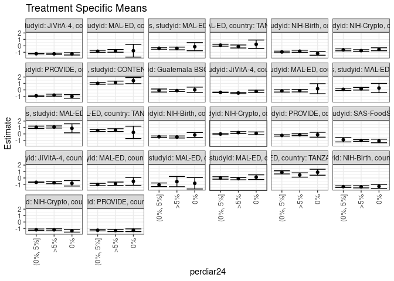

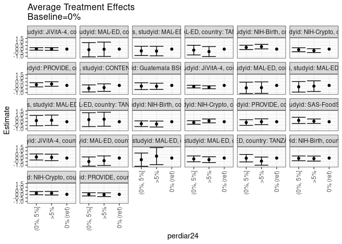

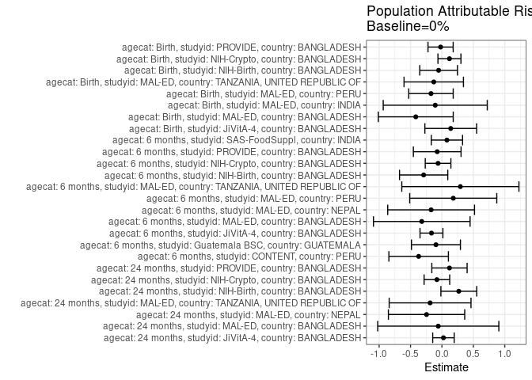

## Results Table

### Parameter: TSM

| agecat | studyid | country | intervention_level | baseline_level | estimate | ci_lower | ci_upper |
| --- | --- | --- | --- | --- | --- | --- | --- |
| Birth | JiVitA-4 | BANGLADESH | 0% | NA | -0.8285430 | -1.2501039 | -0.4069820 |
| Birth | JiVitA-4 | BANGLADESH | (0%, 5%] | NA | -0.6793484 | -0.7351306 | -0.6235662 |
| Birth | JiVitA-4 | BANGLADESH | >5% | NA | -0.7381767 | -0.8942703 | -0.5820830 |
| Birth | MAL-ED | BANGLADESH | 0% | NA | -0.5253498 | -1.1416762 | 0.0909767 |
| Birth | MAL-ED | BANGLADESH | (0%, 5%] | NA | -1.0121241 | -1.1942996 | -0.8299487 |
| Birth | MAL-ED | BANGLADESH | >5% | NA | -0.8967055 | -1.1575546 | -0.6358565 |
| Birth | MAL-ED | INDIA | 0% | NA | -0.8260000 | -1.7120476 | 0.0600476 |
| Birth | MAL-ED | INDIA | (0%, 5%] | NA | -1.0574194 | -1.3366625 | -0.7781762 |
| Birth | MAL-ED | INDIA | >5% | NA | -0.5611111 | -1.3534381 | 0.2312159 |
| Birth | MAL-ED | PERU | 0% | NA | 0.1223724 | -0.2420515 | 0.4867963 |
| Birth | MAL-ED | PERU | (0%, 5%] | NA | 0.0020242 | -0.1875072 | 0.1915556 |
| Birth | MAL-ED | PERU | >5% | NA | -0.1052915 | -0.2793077 | 0.0687248 |
| Birth | MAL-ED | TANZANIA, UNITED REPUBLIC OF | 0% | NA | 0.8928571 | 0.4313181 | 1.3543962 |
| Birth | MAL-ED | TANZANIA, UNITED REPUBLIC OF | (0%, 5%] | NA | 0.8712987 | 0.6273536 | 1.1152438 |
| Birth | MAL-ED | TANZANIA, UNITED REPUBLIC OF | >5% | NA | 0.4625806 | 0.1300967 | 0.7950646 |
| Birth | NIH-Birth | BANGLADESH | 0% | NA | -1.2997967 | -1.6082544 | -0.9913390 |
| Birth | NIH-Birth | BANGLADESH | (0%, 5%] | NA | -1.3459825 | -1.4718920 | -1.2200730 |
| Birth | NIH-Birth | BANGLADESH | >5% | NA | -1.3757870 | -1.5402310 | -1.2113429 |
| Birth | NIH-Crypto | BANGLADESH | 0% | NA | -1.3636868 | -1.5697550 | -1.1576185 |
| Birth | NIH-Crypto | BANGLADESH | (0%, 5%] | NA | -1.2013991 | -1.3186582 | -1.0841400 |
| Birth | NIH-Crypto | BANGLADESH | >5% | NA | -1.2057050 | -1.3559124 | -1.0554977 |
| Birth | PROVIDE | BANGLADESH | 0% | NA | -1.2770429 | -1.4861449 | -1.0679408 |
| Birth | PROVIDE | BANGLADESH | (0%, 5%] | NA | -1.2751627 | -1.3711396 | -1.1791859 |
| Birth | PROVIDE | BANGLADESH | >5% | NA | -1.3293678 | -1.4843776 | -1.1743580 |
| 6 months | CONTENT | PERU | 0% | NA | 1.4351667 | 0.9626985 | 1.9076349 |
| 6 months | CONTENT | PERU | (0%, 5%] | NA | 1.0176514 | 0.8796884 | 1.1556144 |
| 6 months | CONTENT | PERU | >5% | NA | 1.1303657 | 0.8984202 | 1.3623112 |
| 6 months | Guatemala BSC | GUATEMALA | 0% | NA | 0.0115316 | -0.4029560 | 0.4260191 |
| 6 months | Guatemala BSC | GUATEMALA | (0%, 5%] | NA | -0.0969712 | -0.3325944 | 0.1386520 |
| 6 months | Guatemala BSC | GUATEMALA | >5% | NA | -0.1108810 | -0.2425519 | 0.0207898 |
| 6 months | JiVitA-4 | BANGLADESH | 0% | NA | -0.2230141 | -0.4098097 | -0.0362186 |
| 6 months | JiVitA-4 | BANGLADESH | (0%, 5%] | NA | -0.3854635 | -0.4244141 | -0.3465128 |
| 6 months | JiVitA-4 | BANGLADESH | >5% | NA | -0.4855364 | -0.5839176 | -0.3871551 |
| 6 months | MAL-ED | BANGLADESH | 0% | NA | 0.1833333 | -0.5948965 | 0.9615632 |
| 6 months | MAL-ED | BANGLADESH | (0%, 5%] | NA | -0.1581455 | -0.3337303 | 0.0174392 |
| 6 months | MAL-ED | BANGLADESH | >5% | NA | -0.1271326 | -0.3185947 | 0.0643295 |
| 6 months | MAL-ED | NEPAL | 0% | NA | 0.2825802 | -0.4345493 | 0.9997096 |
| 6 months | MAL-ED | NEPAL | (0%, 5%] | NA | 0.0849107 | -0.0878304 | 0.2576517 |
| 6 months | MAL-ED | NEPAL | >5% | NA | 0.1788467 | -0.0281543 | 0.3858478 |
| 6 months | MAL-ED | PERU | 0% | NA | 0.8728571 | 0.1723061 | 1.5734082 |
| 6 months | MAL-ED | PERU | (0%, 5%] | NA | 1.0295260 | 0.8447495 | 1.2143025 |
| 6 months | MAL-ED | PERU | >5% | NA | 1.0771231 | 0.9121893 | 1.2420570 |
| 6 months | MAL-ED | TANZANIA, UNITED REPUBLIC OF | 0% | NA | 0.2427778 | -0.7161220 | 1.2016775 |
| 6 months | MAL-ED | TANZANIA, UNITED REPUBLIC OF | (0%, 5%] | NA | 0.5318644 | 0.3720281 | 0.6917007 |
| 6 months | MAL-ED | TANZANIA, UNITED REPUBLIC OF | >5% | NA | 0.5921585 | 0.3766024 | 0.8077146 |
| 6 months | NIH-Birth | BANGLADESH | 0% | NA | -0.1562557 | -0.5390127 | 0.2265013 |
| 6 months | NIH-Birth | BANGLADESH | (0%, 5%] | NA | -0.4383524 | -0.5556261 | -0.3210786 |
| 6 months | NIH-Birth | BANGLADESH | >5% | NA | -0.4786370 | -0.6360890 | -0.3211850 |
| 6 months | NIH-Crypto | BANGLADESH | 0% | NA | 0.0912678 | -0.1278481 | 0.3103837 |
| 6 months | NIH-Crypto | BANGLADESH | (0%, 5%] | NA | -0.0129626 | -0.1288725 | 0.1029472 |
| 6 months | NIH-Crypto | BANGLADESH | >5% | NA | 0.2030857 | 0.0521201 | 0.3540513 |
| 6 months | PROVIDE | BANGLADESH | 0% | NA | -0.1238653 | -0.5032136 | 0.2554830 |
| 6 months | PROVIDE | BANGLADESH | (0%, 5%] | NA | -0.2354130 | -0.3382970 | -0.1325291 |
| 6 months | PROVIDE | BANGLADESH | >5% | NA | -0.1264524 | -0.2742432 | 0.0213383 |
| 6 months | SAS-FoodSuppl | INDIA | 0% | NA | -1.0915645 | -1.3664201 | -0.8167089 |
| 6 months | SAS-FoodSuppl | INDIA | (0%, 5%] | NA | -0.9022533 | -1.2406944 | -0.5638122 |
| 6 months | SAS-FoodSuppl | INDIA | >5% | NA | -1.0211463 | -1.1624345 | -0.8798580 |
| 24 months | JiVitA-4 | BANGLADESH | 0% | NA | -1.2471520 | -1.4242213 | -1.0700828 |
| 24 months | JiVitA-4 | BANGLADESH | (0%, 5%] | NA | -1.2194537 | -1.2522598 | -1.1866475 |
| 24 months | JiVitA-4 | BANGLADESH | >5% | NA | -1.2339403 | -1.3209629 | -1.1469177 |
| 24 months | MAL-ED | BANGLADESH | 0% | NA | -0.7608333 | -1.7455859 | 0.2239193 |
| 24 months | MAL-ED | BANGLADESH | (0%, 5%] | NA | -0.8440769 | -0.9945327 | -0.6936211 |
| 24 months | MAL-ED | BANGLADESH | >5% | NA | -0.7815132 | -0.9897171 | -0.5733093 |
| 24 months | MAL-ED | NEPAL | 0% | NA | -0.1300236 | -0.7585713 | 0.4985242 |
| 24 months | MAL-ED | NEPAL | (0%, 5%] | NA | -0.3839704 | -0.5227677 | -0.2451731 |
| 24 months | MAL-ED | NEPAL | >5% | NA | -0.4067199 | -0.6160983 | -0.1973415 |
| 24 months | MAL-ED | TANZANIA, UNITED REPUBLIC OF | 0% | NA | 0.2433333 | -0.4146176 | 0.9012843 |
| 24 months | MAL-ED | TANZANIA, UNITED REPUBLIC OF | (0%, 5%] | NA | 0.0989530 | -0.0508664 | 0.2487724 |
| 24 months | MAL-ED | TANZANIA, UNITED REPUBLIC OF | >5% | NA | -0.0994231 | -0.3337823 | 0.1349362 |
| 24 months | NIH-Birth | BANGLADESH | 0% | NA | -1.1800000 | -1.4547770 | -0.9052230 |
| 24 months | NIH-Birth | BANGLADESH | (0%, 5%] | NA | -0.9456415 | -1.0692081 | -0.8220748 |
| 24 months | NIH-Birth | BANGLADESH | >5% | NA | -0.8370172 | -1.0005302 | -0.6735043 |
| 24 months | NIH-Crypto | BANGLADESH | 0% | NA | -0.5301456 | -0.7625323 | -0.2977589 |
| 24 months | NIH-Crypto | BANGLADESH | (0%, 5%] | NA | -0.6172279 | -0.7704078 | -0.4640480 |
| 24 months | NIH-Crypto | BANGLADESH | >5% | NA | -0.7440283 | -0.8850112 | -0.6030453 |
| 24 months | PROVIDE | BANGLADESH | 0% | NA | -1.0127778 | -1.2883897 | -0.7371658 |
| 24 months | PROVIDE | BANGLADESH | (0%, 5%] | NA | -0.9233081 | -1.0226788 | -0.8239373 |
| 24 months | PROVIDE | BANGLADESH | >5% | NA | -0.8173851 | -0.9715768 | -0.6631933 |

### Parameter: E(Y)

| agecat | studyid | country | intervention_level | baseline_level | estimate | ci_lower | ci_upper |
| --- | --- | --- | --- | --- | --- | --- | --- |
| Birth | JiVitA-4 | BANGLADESH | NA | NA | -0.6886269 | -0.7410452 | -0.6362086 |
| Birth | MAL-ED | BANGLADESH | NA | NA | -0.9418605 | -1.0869834 | -0.7967375 |
| Birth | MAL-ED | INDIA | NA | NA | -0.9324444 | -1.2067907 | -0.6580982 |
| Birth | MAL-ED | PERU | NA | NA | -0.0520175 | -0.1725298 | 0.0684947 |
| Birth | MAL-ED | TANZANIA, UNITED REPUBLIC OF | NA | NA | 0.7624348 | 0.5710709 | 0.9537986 |
| Birth | NIH-Birth | BANGLADESH | NA | NA | -1.3525437 | -1.4473932 | -1.2576942 |
| Birth | NIH-Crypto | BANGLADESH | NA | NA | -1.2441513 | -1.3281130 | -1.1601897 |
| Birth | PROVIDE | BANGLADESH | NA | NA | -1.2984586 | -1.3752758 | -1.2216415 |
| 6 months | CONTENT | PERU | NA | NA | 1.0644279 | 0.9468682 | 1.1819876 |
| 6 months | Guatemala BSC | GUATEMALA | NA | NA | -0.0840134 | -0.1945572 | 0.0265305 |
| 6 months | JiVitA-4 | BANGLADESH | NA | NA | -0.3898055 | -0.4270507 | -0.3525603 |
| 6 months | MAL-ED | BANGLADESH | NA | NA | -0.1376763 | -0.2664642 | -0.0088885 |
| 6 months | MAL-ED | NEPAL | NA | NA | 0.1104308 | -0.0208643 | 0.2417259 |
| 6 months | MAL-ED | PERU | NA | NA | 1.0528816 | 0.9313005 | 1.1744626 |
| 6 months | MAL-ED | TANZANIA, UNITED REPUBLIC OF | NA | NA | 0.5362213 | 0.4049390 | 0.6675036 |
| 6 months | NIH-Birth | BANGLADESH | NA | NA | -0.4474038 | -0.5378167 | -0.3569909 |
| 6 months | NIH-Crypto | BANGLADESH | NA | NA | 0.0297622 | -0.0491685 | 0.1086930 |
| 6 months | PROVIDE | BANGLADESH | NA | NA | -0.1990907 | -0.2817968 | -0.1163845 |
| 6 months | SAS-FoodSuppl | INDIA | NA | NA | -1.0121579 | -1.1280429 | -0.8962729 |
| 24 months | JiVitA-4 | BANGLADESH | NA | NA | -1.2231088 | -1.2549632 | -1.1912543 |
| 24 months | MAL-ED | BANGLADESH | NA | NA | -0.8192925 | -0.9412667 | -0.6973182 |
| 24 months | MAL-ED | NEPAL | NA | NA | -0.3749123 | -0.4886073 | -0.2612173 |
| 24 months | MAL-ED | TANZANIA, UNITED REPUBLIC OF | NA | NA | 0.0547975 | -0.0703378 | 0.1799328 |
| 24 months | NIH-Birth | BANGLADESH | NA | NA | -0.9115790 | -1.0095022 | -0.8136559 |
| 24 months | NIH-Crypto | BANGLADESH | NA | NA | -0.6103502 | -0.7050157 | -0.5156847 |
| 24 months | PROVIDE | BANGLADESH | NA | NA | -0.8928670 | -0.9755153 | -0.8102187 |

### Parameter: ATE

| agecat | studyid | country | intervention_level | baseline_level | estimate | ci_lower | ci_upper |
| --- | --- | --- | --- | --- | --- | --- | --- |
| Birth | JiVitA-4 | BANGLADESH | 0% | 0% | 0.0000000 | 0.0000000 | 0.0000000 |
| Birth | JiVitA-4 | BANGLADESH | (0%, 5%] | 0% | 0.1491945 | -0.2739448 | 0.5723339 |
| Birth | JiVitA-4 | BANGLADESH | >5% | 0% | 0.0903663 | -0.3601818 | 0.5409143 |
| Birth | MAL-ED | BANGLADESH | 0% | 0% | 0.0000000 | 0.0000000 | 0.0000000 |
| Birth | MAL-ED | BANGLADESH | (0%, 5%] | 0% | -0.4867744 | -1.1296521 | 0.1561034 |
| Birth | MAL-ED | BANGLADESH | >5% | 0% | -0.3713557 | -1.0406444 | 0.2979329 |
| Birth | MAL-ED | INDIA | 0% | 0% | 0.0000000 | 0.0000000 | 0.0000000 |
| Birth | MAL-ED | INDIA | (0%, 5%] | 0% | -0.2314194 | -1.1604280 | 0.6975893 |
| Birth | MAL-ED | INDIA | >5% | 0% | 0.2648889 | -0.9237500 | 1.4535278 |
| Birth | MAL-ED | PERU | 0% | 0% | 0.0000000 | 0.0000000 | 0.0000000 |
| Birth | MAL-ED | PERU | (0%, 5%] | 0% | -0.1203482 | -0.5318613 | 0.2911648 |
| Birth | MAL-ED | PERU | >5% | 0% | -0.2276639 | -0.6320117 | 0.1766839 |
| Birth | MAL-ED | TANZANIA, UNITED REPUBLIC OF | 0% | 0% | 0.0000000 | 0.0000000 | 0.0000000 |
| Birth | MAL-ED | TANZANIA, UNITED REPUBLIC OF | (0%, 5%] | 0% | -0.0215584 | -0.5436001 | 0.5004833 |
| Birth | MAL-ED | TANZANIA, UNITED REPUBLIC OF | >5% | 0% | -0.4302765 | -0.9991033 | 0.1385503 |
| Birth | NIH-Birth | BANGLADESH | 0% | 0% | 0.0000000 | 0.0000000 | 0.0000000 |
| Birth | NIH-Birth | BANGLADESH | (0%, 5%] | 0% | -0.0461858 | -0.3794328 | 0.2870612 |
| Birth | NIH-Birth | BANGLADESH | >5% | 0% | -0.0759903 | -0.4255028 | 0.2735223 |
| Birth | NIH-Crypto | BANGLADESH | 0% | 0% | 0.0000000 | 0.0000000 | 0.0000000 |
| Birth | NIH-Crypto | BANGLADESH | (0%, 5%] | 0% | 0.1622876 | -0.0695261 | 0.3941013 |
| Birth | NIH-Crypto | BANGLADESH | >5% | 0% | 0.1579817 | -0.0922232 | 0.4081867 |
| Birth | PROVIDE | BANGLADESH | 0% | 0% | 0.0000000 | 0.0000000 | 0.0000000 |
| Birth | PROVIDE | BANGLADESH | (0%, 5%] | 0% | 0.0018801 | -0.2243488 | 0.2281091 |
| Birth | PROVIDE | BANGLADESH | >5% | 0% | -0.0523250 | -0.3087310 | 0.2040810 |
| 6 months | CONTENT | PERU | 0% | 0% | 0.0000000 | 0.0000000 | 0.0000000 |
| 6 months | CONTENT | PERU | (0%, 5%] | 0% | -0.4175153 | -0.9097144 | 0.0746839 |
| 6 months | CONTENT | PERU | >5% | 0% | -0.3048010 | -0.8311326 | 0.2215306 |
| 6 months | Guatemala BSC | GUATEMALA | 0% | 0% | 0.0000000 | 0.0000000 | 0.0000000 |
| 6 months | Guatemala BSC | GUATEMALA | (0%, 5%] | 0% | -0.1085028 | -0.5852425 | 0.3682370 |
| 6 months | Guatemala BSC | GUATEMALA | >5% | 0% | -0.1224126 | -0.5575777 | 0.3127526 |
| 6 months | JiVitA-4 | BANGLADESH | 0% | 0% | 0.0000000 | 0.0000000 | 0.0000000 |
| 6 months | JiVitA-4 | BANGLADESH | (0%, 5%] | 0% | -0.1624493 | -0.3506905 | 0.0257918 |
| 6 months | JiVitA-4 | BANGLADESH | >5% | 0% | -0.2625222 | -0.4683852 | -0.0566593 |
| 6 months | MAL-ED | BANGLADESH | 0% | 0% | 0.0000000 | 0.0000000 | 0.0000000 |
| 6 months | MAL-ED | BANGLADESH | (0%, 5%] | 0% | -0.3414789 | -1.1392706 | 0.4563129 |
| 6 months | MAL-ED | BANGLADESH | >5% | 0% | -0.3104659 | -1.1119018 | 0.4909699 |
| 6 months | MAL-ED | NEPAL | 0% | 0% | 0.0000000 | 0.0000000 | 0.0000000 |
| 6 months | MAL-ED | NEPAL | (0%, 5%] | 0% | -0.1976695 | -0.9358288 | 0.5404898 |
| 6 months | MAL-ED | NEPAL | >5% | 0% | -0.1037334 | -0.8503807 | 0.6429139 |
| 6 months | MAL-ED | PERU | 0% | 0% | 0.0000000 | 0.0000000 | 0.0000000 |
| 6 months | MAL-ED | PERU | (0%, 5%] | 0% | 0.1566689 | -0.5678407 | 0.8811784 |
| 6 months | MAL-ED | PERU | >5% | 0% | 0.2042660 | -0.5154387 | 0.9239707 |
| 6 months | MAL-ED | TANZANIA, UNITED REPUBLIC OF | 0% | 0% | 0.0000000 | 0.0000000 | 0.0000000 |
| 6 months | MAL-ED | TANZANIA, UNITED REPUBLIC OF | (0%, 5%] | 0% | 0.2890866 | -0.6830432 | 1.2612164 |
| 6 months | MAL-ED | TANZANIA, UNITED REPUBLIC OF | >5% | 0% | 0.3493807 | -0.6334485 | 1.3322099 |
| 6 months | NIH-Birth | BANGLADESH | 0% | 0% | 0.0000000 | 0.0000000 | 0.0000000 |
| 6 months | NIH-Birth | BANGLADESH | (0%, 5%] | 0% | -0.2820967 | -0.6832344 | 0.1190410 |
| 6 months | NIH-Birth | BANGLADESH | >5% | 0% | -0.3223813 | -0.7368151 | 0.0920524 |
| 6 months | NIH-Crypto | BANGLADESH | 0% | 0% | 0.0000000 | 0.0000000 | 0.0000000 |
| 6 months | NIH-Crypto | BANGLADESH | (0%, 5%] | 0% | -0.1042304 | -0.3518300 | 0.1433692 |
| 6 months | NIH-Crypto | BANGLADESH | >5% | 0% | 0.1118179 | -0.1545218 | 0.3781576 |
| 6 months | PROVIDE | BANGLADESH | 0% | 0% | 0.0000000 | 0.0000000 | 0.0000000 |
| 6 months | PROVIDE | BANGLADESH | (0%, 5%] | 0% | -0.1115477 | -0.5050190 | 0.2819235 |
| 6 months | PROVIDE | BANGLADESH | >5% | 0% | -0.0025871 | -0.4100281 | 0.4048539 |
| 6 months | SAS-FoodSuppl | INDIA | 0% | 0% | 0.0000000 | 0.0000000 | 0.0000000 |
| 6 months | SAS-FoodSuppl | INDIA | (0%, 5%] | 0% | 0.1893112 | -0.2482069 | 0.6268293 |
| 6 months | SAS-FoodSuppl | INDIA | >5% | 0% | 0.0704182 | -0.2409444 | 0.3817808 |
| 24 months | JiVitA-4 | BANGLADESH | 0% | 0% | 0.0000000 | 0.0000000 | 0.0000000 |
| 24 months | JiVitA-4 | BANGLADESH | (0%, 5%] | 0% | 0.0276984 | -0.1495745 | 0.2049713 |
| 24 months | JiVitA-4 | BANGLADESH | >5% | 0% | 0.0132118 | -0.1814212 | 0.2078447 |
| 24 months | MAL-ED | BANGLADESH | 0% | 0% | 0.0000000 | 0.0000000 | 0.0000000 |
| 24 months | MAL-ED | BANGLADESH | (0%, 5%] | 0% | -0.0832436 | -1.0794236 | 0.9129364 |
| 24 months | MAL-ED | BANGLADESH | >5% | 0% | -0.0206798 | -1.0272018 | 0.9858422 |
| 24 months | MAL-ED | NEPAL | 0% | 0% | 0.0000000 | 0.0000000 | 0.0000000 |
| 24 months | MAL-ED | NEPAL | (0%, 5%] | 0% | -0.2539468 | -0.8968658 | 0.3889721 |
| 24 months | MAL-ED | NEPAL | >5% | 0% | -0.2766964 | -0.9382718 | 0.3848790 |
| 24 months | MAL-ED | TANZANIA, UNITED REPUBLIC OF | 0% | 0% | 0.0000000 | 0.0000000 | 0.0000000 |
| 24 months | MAL-ED | TANZANIA, UNITED REPUBLIC OF | (0%, 5%] | 0% | -0.1443803 | -0.8191731 | 0.5304124 |
| 24 months | MAL-ED | TANZANIA, UNITED REPUBLIC OF | >5% | 0% | -0.3427564 | -1.0412002 | 0.3556873 |
| 24 months | NIH-Birth | BANGLADESH | 0% | 0% | 0.0000000 | 0.0000000 | 0.0000000 |
| 24 months | NIH-Birth | BANGLADESH | (0%, 5%] | 0% | 0.2343585 | -0.0669240 | 0.5356410 |
| 24 months | NIH-Birth | BANGLADESH | >5% | 0% | 0.3429828 | 0.0232346 | 0.6627310 |
| 24 months | NIH-Crypto | BANGLADESH | 0% | 0% | 0.0000000 | 0.0000000 | 0.0000000 |
| 24 months | NIH-Crypto | BANGLADESH | (0%, 5%] | 0% | -0.0870823 | -0.3653520 | 0.1911874 |
| 24 months | NIH-Crypto | BANGLADESH | >5% | 0% | -0.2138826 | -0.4859687 | 0.0582035 |
| 24 months | PROVIDE | BANGLADESH | 0% | 0% | 0.0000000 | 0.0000000 | 0.0000000 |
| 24 months | PROVIDE | BANGLADESH | (0%, 5%] | 0% | 0.0894697 | -0.2035090 | 0.3824484 |
| 24 months | PROVIDE | BANGLADESH | >5% | 0% | 0.1953927 | -0.1204190 | 0.5112044 |

### Parameter: PAR

| agecat | studyid | country | intervention_level | baseline_level | estimate | ci_lower | ci_upper |
| --- | --- | --- | --- | --- | --- | --- | --- |
| Birth | JiVitA-4 | BANGLADESH | 0% | NA | 0.1399161 | -0.2720897 | 0.5519219 |
| Birth | MAL-ED | BANGLADESH | 0% | NA | -0.4165107 | -1.0129623 | 0.1799409 |
| Birth | MAL-ED | INDIA | 0% | NA | -0.1064444 | -0.9346255 | 0.7217366 |
| Birth | MAL-ED | PERU | 0% | NA | -0.1743899 | -0.5283574 | 0.1795775 |
| Birth | MAL-ED | TANZANIA, UNITED REPUBLIC OF | 0% | NA | -0.1304224 | -0.6033978 | 0.3425531 |
| Birth | NIH-Birth | BANGLADESH | 0% | NA | -0.0527470 | -0.3526084 | 0.2471144 |
| Birth | NIH-Crypto | BANGLADESH | 0% | NA | 0.1195354 | -0.0634647 | 0.3025355 |
| Birth | PROVIDE | BANGLADESH | 0% | NA | -0.0214158 | -0.2218044 | 0.1789728 |
| 6 months | CONTENT | PERU | 0% | NA | -0.3707388 | -0.8446452 | 0.1031677 |
| 6 months | Guatemala BSC | GUATEMALA | 0% | NA | -0.0955450 | -0.4854195 | 0.2943296 |
| 6 months | JiVitA-4 | BANGLADESH | 0% | NA | -0.1667914 | -0.3489946 | 0.0154119 |
| 6 months | MAL-ED | BANGLADESH | 0% | NA | -0.3210097 | -1.0903899 | 0.4483705 |
| 6 months | MAL-ED | NEPAL | 0% | NA | -0.1721494 | -0.8630644 | 0.5187656 |
| 6 months | MAL-ED | PERU | 0% | NA | 0.1800244 | -0.5130743 | 0.8731232 |
| 6 months | MAL-ED | TANZANIA, UNITED REPUBLIC OF | 0% | NA | 0.2934435 | -0.6391424 | 1.2260295 |
| 6 months | NIH-Birth | BANGLADESH | 0% | NA | -0.2911481 | -0.6753315 | 0.0930353 |
| 6 months | NIH-Crypto | BANGLADESH | 0% | NA | -0.0615056 | -0.2656367 | 0.1426256 |
| 6 months | PROVIDE | BANGLADESH | 0% | NA | -0.0752253 | -0.4548503 | 0.3043997 |
| 6 months | SAS-FoodSuppl | INDIA | 0% | NA | 0.0794066 | -0.1694925 | 0.3283057 |
| 24 months | JiVitA-4 | BANGLADESH | 0% | NA | 0.0240433 | -0.1469916 | 0.1950781 |
| 24 months | MAL-ED | BANGLADESH | 0% | NA | -0.0584591 | -1.0226814 | 0.9057631 |
| 24 months | MAL-ED | NEPAL | 0% | NA | -0.2448887 | -0.8524625 | 0.3626851 |
| 24 months | MAL-ED | TANZANIA, UNITED REPUBLIC OF | 0% | NA | -0.1885358 | -0.8399063 | 0.4628347 |
| 24 months | NIH-Birth | BANGLADESH | 0% | NA | 0.2684210 | -0.0167391 | 0.5535810 |
| 24 months | NIH-Crypto | BANGLADESH | 0% | NA | -0.0802046 | -0.2839824 | 0.1235733 |
| 24 months | PROVIDE | BANGLADESH | 0% | NA | 0.1199108 | -0.1611490 | 0.4009705 |